#Regression model anaylsis part

#Task 1 - Preliminary Data Analysis Part #This is the first part of the assignment where the dataset is loaded and the trends of the data is studies

```r
data <- read.csv("C:/Masters Study Materials/Assignment/dataset.csv")
head(data)
```

```
##      x1    x3      x4    x5     x2
## 1  8.34 40.77 1010.84 90.01 480.48
## 2 23.64 58.49 1011.40 74.20 445.75
## 3 29.74 56.90 1007.15 41.91 438.76
## 4 19.07 49.69 1007.22 76.79 453.09
## 5 11.80 40.66 1017.13 97.20 464.43
## 6 13.97 39.16 1016.05 84.60 470.96
```

#Create time index and select input and output columns from the data

```r
t <- 1:nrow(data)
write.csv(data.frame(t = t), "t.csv", row.names = FALSE, col.names = FALSE, sep = ",")
# Extract numeric input variables and ensure they are properly typed
x <- data[, c("x1", "x3", "x4", "x5")]
x <- as.data.frame(lapply(x, as.numeric))  # Ensures all columns are numeric
write.table(x, "x.csv", row.names = FALSE, col.names = FALSE, sep = ",")

# Extract the output variable (x2) and ensure it's numeric
y <- as.numeric(data[, "x2"])
write.table(data.frame(y), "y.csv", row.names = FALSE, col.names = FALSE, sep = ",")

# Create time index and save without column name
t <- 1:nrow(data)
write.table(data.frame(t), "t.csv", row.names = FALSE, col.names = FALSE, sep = ",")
```

#importing the needed libraries

```r
library(matlib)
library(ggplot2)
library(rsample)
```

#importing input data from csv file

```r
X=as.matrix(read.csv(file="C:/Masters Study Materials/Assignment/pp_assignment/x.csv",header = F))
colnames(X)<-c("x1","x3","x4","x5")
```

#displaying imported input data

```r
X
```

```
##            x1    x3      x4     x5
##    [1,]  8.34 40.77 1010.84  90.01
##    [2,] 23.64 58.49 1011.40  74.20
##    [3,] 29.74 56.90 1007.15  41.91
##    [4,] 19.07 49.69 1007.22  76.79
##    [5,] 11.80 40.66 1017.13  97.20
##    [6,] 13.97 39.16 1016.05  84.60
##    [7,] 22.10 71.29 1008.20  75.38
##    [8,] 14.47 41.76 1021.98  78.41
##    [9,] 31.25 69.51 1010.25  36.83
##   [10,]  6.77 38.18 1017.80  81.13
##   [11,] 28.28 68.67 1006.36  69.90
##   [12,] 22.99 46.93 1014.15  49.42
##   [13,] 29.30 70.04 1010.95  61.23
##   [14,]  8.14 37.49 1009.04  80.33
```

[output cut: 9554 more lines]

#importing target output data from csv file

```r
Y=as.matrix(read.csv(file="C:/Masters Study Materials/Assignment/pp_assignment/y.csv",header = F))
colnames(Y)<-c("y")
```

#displaying targeted output data

```r
Y
```

```
##              y
##    [1,] 480.48
##    [2,] 445.75
##    [3,] 438.76
##    [4,] 453.09
##    [5,] 464.43
##    [6,] 470.96
##    [7,] 442.35
##    [8,] 464.00
##    [9,] 428.77
##   [10,] 484.31
##   [11,] 435.29
##   [12,] 451.41
##   [13,] 426.25
##   [14,] 480.66
```

[output cut: 9554 more lines]

#importing time series data from csv file

```r
time = read.csv("C:/Masters Study Materials/Assignment/pp_assignment/t.csv", header = F)
time = as.matrix(time)
```

#displaying the importe time series data

```r
time
```

```
##           V1
##    [1,]    1
##    [2,]    2
##    [3,]    3
##    [4,]    4
##    [5,]    5
##    [6,]    6
##    [7,]    7
##    [8,]    8
##    [9,]    9
##   [10,]   10
##   [11,]   11
##   [12,]   12
##   [13,]   13
##   [14,]   14
```

[output cut: 9554 more lines]

#TASKS

#Task 1.1 - Plotting Time Series Data

#converts x and y into time series objects for plotting

```r
X.ts <- ts(X, start = 1, frequency = 1)
Y.ts <- ts(Y, start = 1, frequency = 1)
```

#plotting timeseries data of input and target variable from the above time series objects

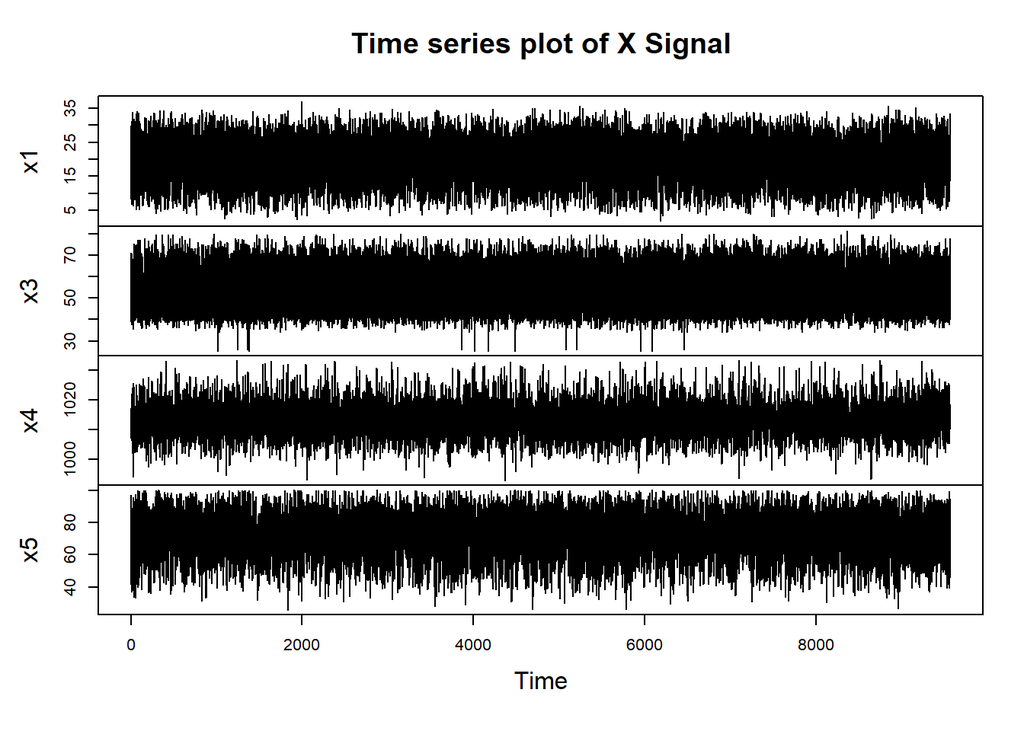

```r
plot(X.ts,main = "Time series plot of X Signal", xlab = "Time", ylab = "Input signal")
```

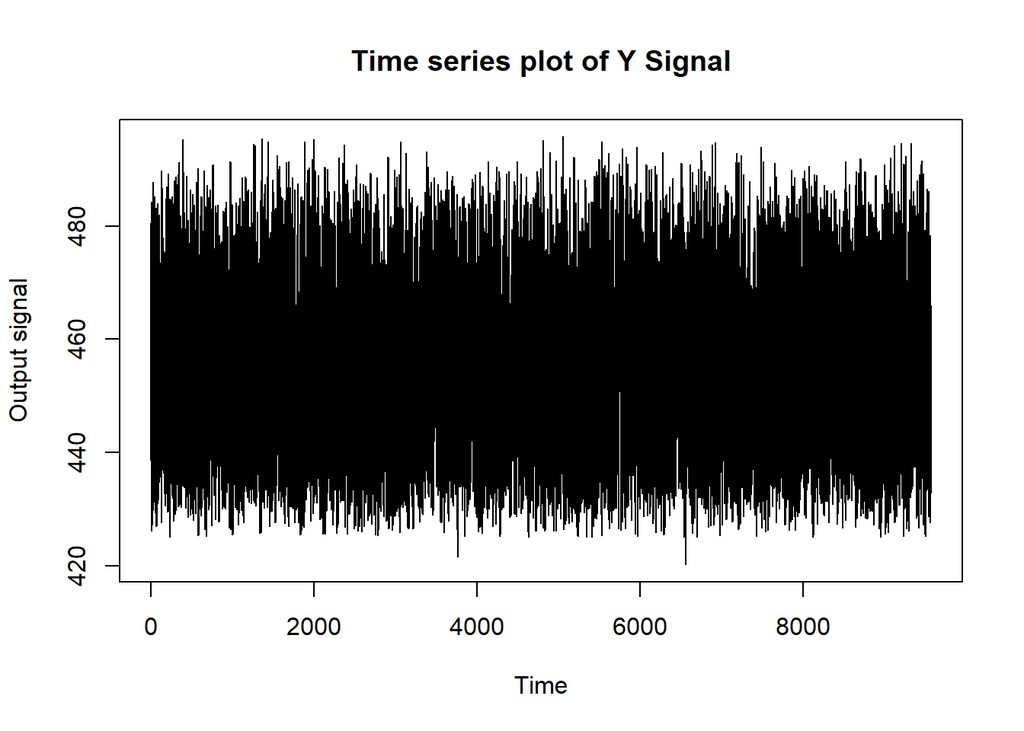

```r
plot(Y.ts,main = "Time series plot of Y Signal", xlab = "Time", ylab = "Output signal")
```